# data

## trainingset_v1d1_metadata

A 7,966 row by 21 column dataframe

###### (note: all times given in UTC)

- `event_time`: The time of the event
- `ifo`: The interferometer that the event was detected at; `H1` = Hanford, `L1` = Livingston
- `peak_time`: The time of the peak of the event up to the second mark
- `peak_time_ns`: The time of the peak of the event in nanoseconds
- `start_time`: The time of the start of the event
- `start_time_ns`: The time of the start of the event in nanoseconds
- `duration`: The duration of the event in seconds
- `event_id`: The ID of the event
- `peak_frequency`: The dominant frequency at the peak of the event.
- `central_freq`: The central frequency at the peak of the event
- `bandwidth`: The distance between the lowest-frequency and highest-frequency points of the event
- `amplitude`: The amplitude of the event
- `snr`: The signal-to-noise ratio of the event; a measurement of how loud the event is, defined as the strength of the signal over the strength of the background noise.
- `gravityspy_id`: The ID of the event on the Gravity Spy citizen science project, which can be used to access the metadata of the event on [the Gravity Spy tools page](https://gravityspytools.ciera.northwestern.edu/).
- `label`: The glitch class that the event was classified as.
- `sample_type`: The type of sample that the event was detected with
- `url1`: The URL of the image of the central 0.5 seconds of the event
- `url2`: The URL of the image of the central second of the event
- `url3`: The URL of the image of the central 2 seconds of the event
- `url4`: The URL of the image of the central 4 seconds of the event
- `phase`: The phase value of the waveform of the event

###### Data from:

###### Coughlin, S. (2018). Gravity Spy Training Set (v1.1.0) [Data set]. Zenodo. https://doi.org/10.5281/zenodo.1486046

## Examples of each glitch class

#### (and their respective acronyms in the [Gravity Spy talk pages](https://www.zooniverse.org/projects/zooniverse/gravity-spy/talk/)):

- 1080 Line:

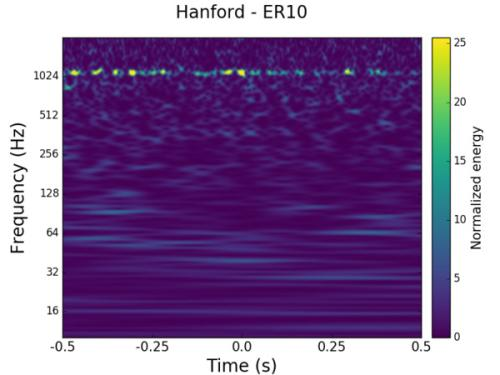

- 1400 Ripple:

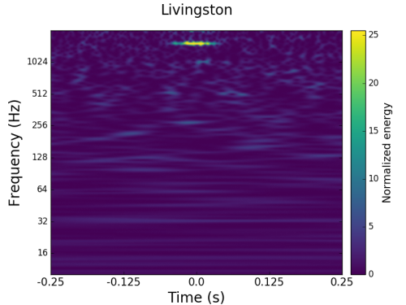

- Air Compressor:

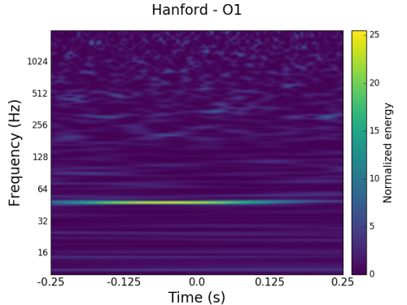

- Blip:

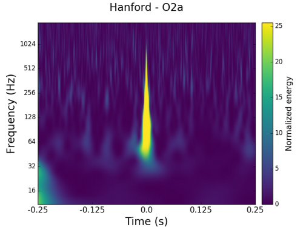

- Chirp:

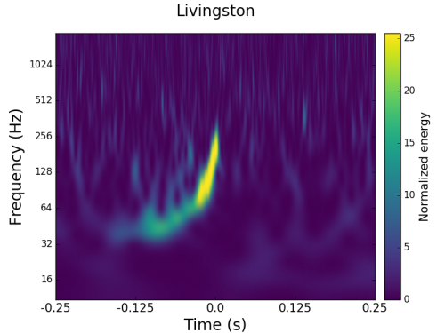

- Extremely Loud (EL):

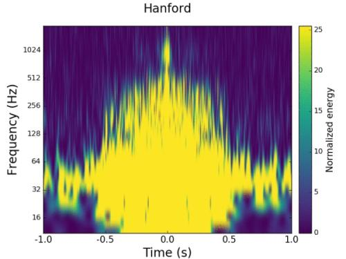

- Helix:

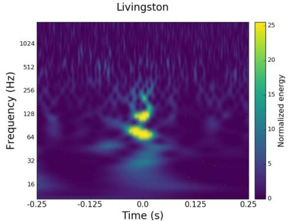

- Koi Fish:

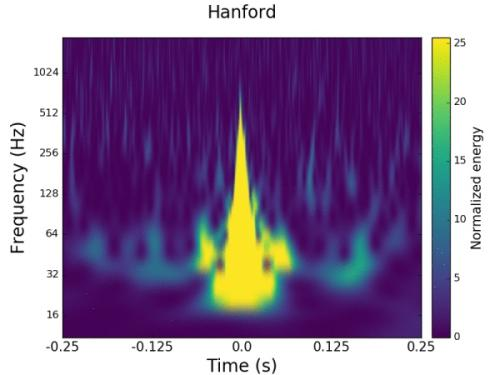

- Light Modulation (LM):

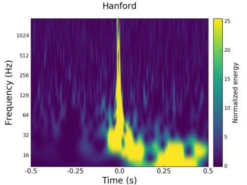

- Low Frequency Burst (LFB*):

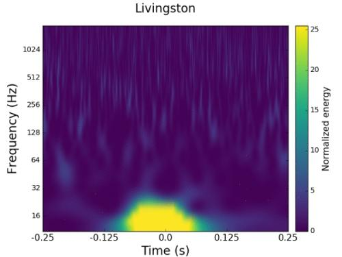

- Low Frequency Line (LFL):

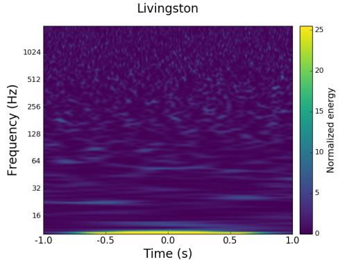

- No Glitch:

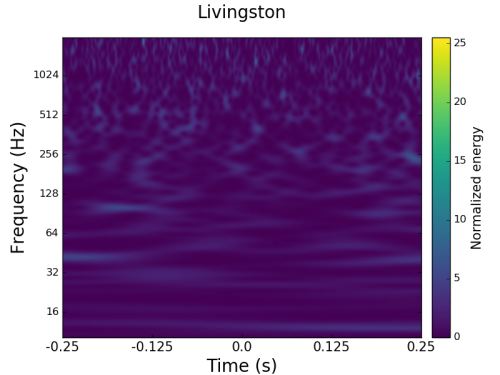

- None of the Above (NOTA):

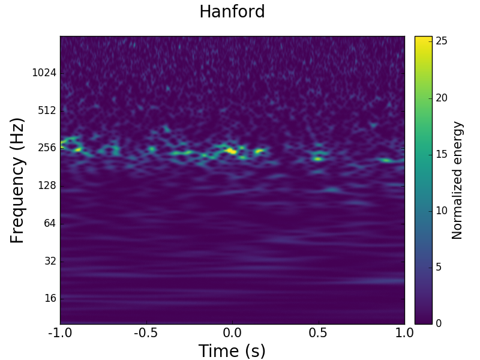

###### (or just anything that doesn’t fit into the other classes)

- Paired Doves (PD):

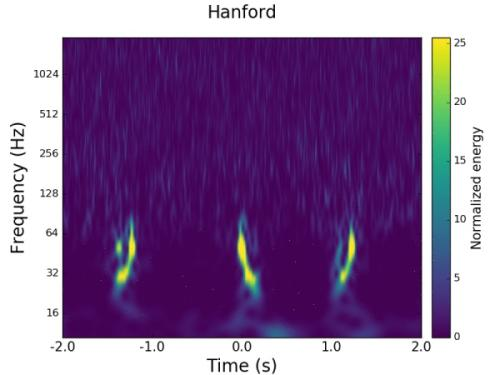

- Power Line:

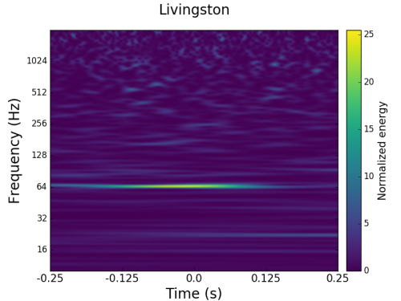

- Repeating Blips:

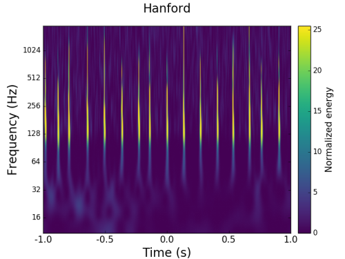

- Scattered Light (SL*):

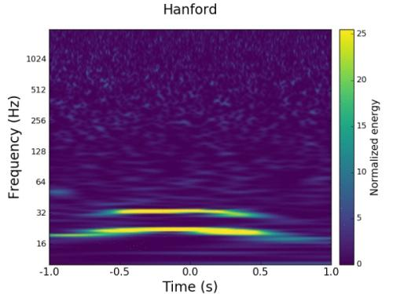

- Scratchy:

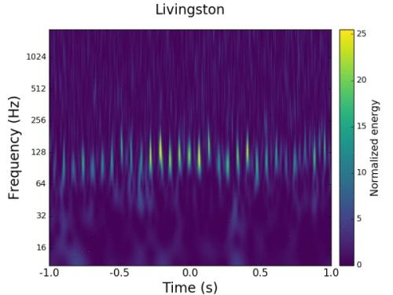

- Tomte:

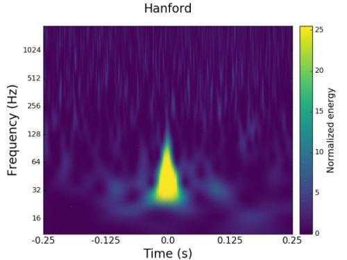

- Violin Mode (aka Violin Mode Harmonics) (VM, VMH):

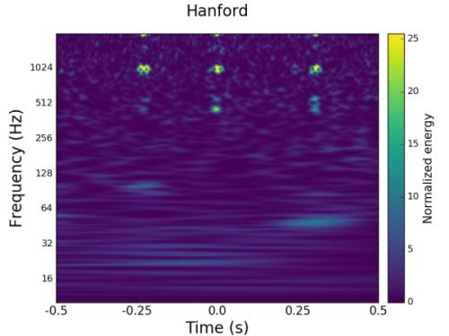

- Wandering Line

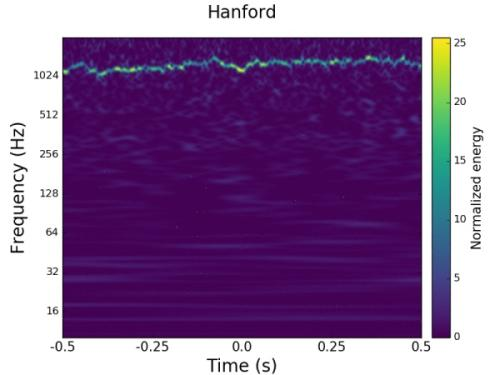

- Whistle

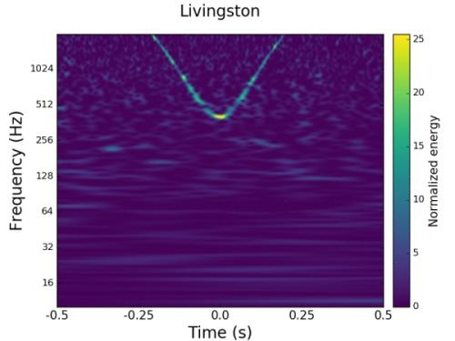

###### *Have had extensive previous use, but used less now due to similarity with other acronyms (the LIGO detectors’ “Slave Lasers” and the more recently introduced glitch class “Low Frequency Blip”)

##### Examples taken from Gravity Spy classifier field guide.